# EPFL Extension School, Elements of Data Science, Project 1

## Part 3

**There is a column (named Sizes) in the dataset that is supposed to group the data in the column Number of employees in the following bins:**

**Small (0 to 20)** **Medium (21 to 50)** **Large (51 to 200)** **Extra large (over 200)** **Unfortunately, somebody made mistakes in that column…**

**Part 3, Question 1**

**Recreate this column correctly,**

**Part 3, Question 2**

**then plot a bar chart with {ggplot2} of the number of values in each of the bins. This is an opportunity to verify that you understand how to add a column in your dataset with values depending on the values of another columns (if other column equal x than this column equal y…)**

**Steps to reach Answer to Part 3, Question 1**

Viewing the columns “Number of employees” and “Sizes” to unveil the incorrect columns.

```r
EmployeesSortinSizes <- survey.csv %>%
  select(`Number of employees`, Sizes)

EmployeesSortinSizes
```

| Number of employees | Sizes |
| --- | --- |
| 15 | Small (1 to 20) |
| 20 | Small (1 to 20) |
| 10 | Small (1 to 20) |
| 191 | Extra large(over 200) |
| 34 | Medium (20 to 50) |
| 79 | Medium (20 to 50) |
| 71 | Large (50 to 200) |
| 75 | Large (50 to 200) |
| 54 | Large (50 to 200) |
| 10 | Small (1 to 20) |

[output cut: 20 more lines]

**Answer to Part 3, Question 1**

Recreating “Sizes” column correctly.

```r
 tableOfEmployeesinCorrectSizes <-
 EmployeesSortinSizes  %>%
  mutate(Sizes = case_when(
    `Number of employees` <=0  |  `Number of employees` <=20  ~ "Small (0 to 20)",
    `Number of employees` <=21  |  `Number of employees` <=50  ~ "Medium (21 to 50)",
    `Number of employees` <=51  |  `Number of employees` <=200  ~ "Large (51 to 200)",
    `Number of employees` >200  ~ "Extra large (over 200)"

  ))

  #mutate to override "Sizes" column with correct values.

tableOfEmployeesinCorrectSizes
```

| Number of employees | Sizes |
| --- | --- |
| 15 | Small (0 to 20) |
| 20 | Small (0 to 20) |
| 10 | Small (0 to 20) |
| 191 | Large (51 to 200) |
| 34 | Medium (21 to 50) |
| 79 | Large (51 to 200) |
| 71 | Large (51 to 200) |
| 75 | Large (51 to 200) |
| 54 | Large (51 to 200) |
| 10 | Small (0 to 20) |

[output cut: 20 more lines]

**Steps to reach Answer to Part 3, Question 2**

Try number of rows per size, not total

```r
numberofentriesperSize <-
tableOfEmployeesinCorrectSizes %>%

  group_by(Sizes)  %>%

  mutate(numberofEntriesperSize = n()) #n() for number of rows per size.

      #%>%
 # ungroup()
#ungroup causes error here


numberofentriesperSize
```

| Number of employees | Sizes | numberofEntriesperSize |
| --- | --- | --- |
| 15 | Small (0 to 20) | 13 |
| 20 | Small (0 to 20) | 13 |
| 10 | Small (0 to 20) | 13 |
| 191 | Large (51 to 200) | 8 |
| 34 | Medium (21 to 50) | 7 |
| 79 | Large (51 to 200) | 8 |
| 71 | Large (51 to 200) | 8 |
| 75 | Large (51 to 200) | 8 |
| 54 | Large (51 to 200) | 8 |
| 10 | Small (0 to 20) | 13 |

[output cut: 20 more lines]

```r
#Removing  `Number of employees` column since we are only interested in Sizes and numberofentriesperSize for the bar-plot.
 SizesandnumberofentriesperSize <-
numberofentriesperSize  %>%
  select(- `Number of employees`)


 SizesandnumberofentriesperSize
```

| Sizes | numberofEntriesperSize |
| --- | --- |
| Small (0 to 20) | 13 |
| Small (0 to 20) | 13 |
| Small (0 to 20) | 13 |
| Large (51 to 200) | 8 |
| Medium (21 to 50) | 7 |
| Large (51 to 200) | 8 |
| Large (51 to 200) | 8 |
| Large (51 to 200) | 8 |
| Large (51 to 200) | 8 |
| Small (0 to 20) | 13 |

[output cut: 20 more lines]

```r
SizesandnumberofentriesperSizeOnlyOnce <-
distinct( SizesandnumberofentriesperSize) %>%

  rename(NumberofParticipants = numberofEntriesperSize)


SizesandnumberofentriesperSizeOnlyOnce
```

| Sizes | NumberofParticipants |
| --- | --- |
| Small (0 to 20) | 13 |
| Large (51 to 200) | 8 |
| Medium (21 to 50) | 7 |
| Extra large (over 200) | 2 |

**Answer to Part 3, Question 2**

Plotting bar chart with {ggplot2} of the number of values in each of the bins.

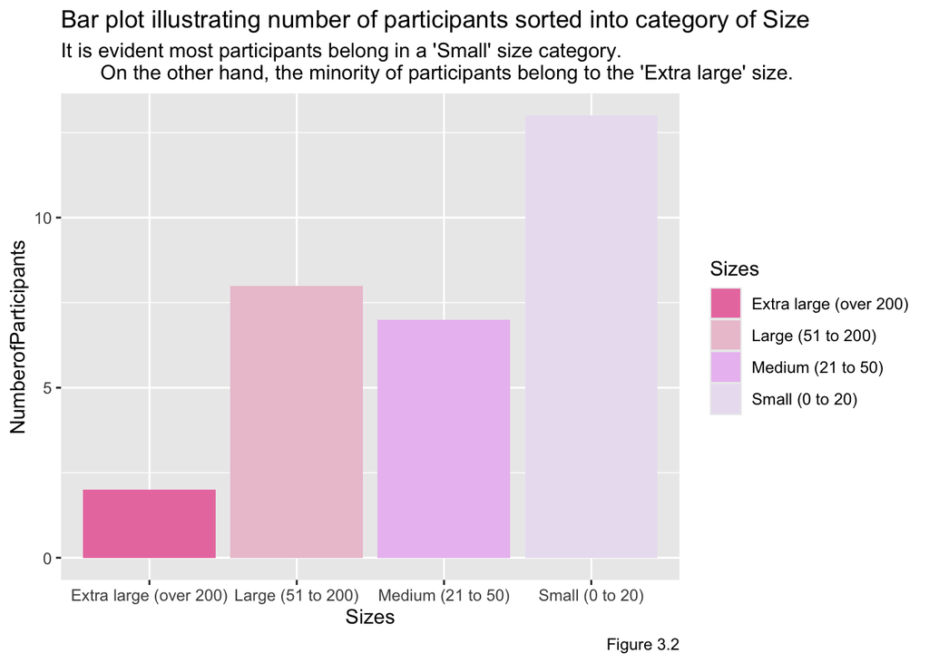

```r
ggplot(data =  SizesandnumberofentriesperSizeOnlyOnce,
mapping = aes(x = NumberofParticipants,
              y = Sizes,
              fill = Sizes)) +
  geom_col() +

  coord_flip() +





  scale_fill_manual(values = c("#EA7DAF",
                             "#ECC4D3",
                             "#EAC1F1",
                             "#EAE2F1"
                             )) +


  labs(title = "Bar plot illustrating number of participants sorted into category of Size",
       subtitle = "It is evident most participants belong in a 'Small' size category.
       On the other hand, the minority of participants belong to the 'Extra large' size.",
       caption = "Figure 3.2")
```

```r
#Note: NEVER wrap ggplot2 column names in quotes. It will produce a strange plot.
```

## Part 4

**Part 4, Question 1**

**Obtain a stacked horizontal bar plot with {ggplot2} that gives the percentage of employees that are Ph.D. students, postdocs and professors for each research group. So now we are interested in calculating and visualising percentage rather than absolute values. This way, all bars in our bar chart will have the same total size and we will be able to see difference in proportions**

**Steps to reach Answer to Part 4, Question 1**

```r
calculatePercentages <-
  #creating tibble to calculate the percentages
original_survey.csv   %>%
  select(-Position, -University, -Sizes) %>%
  # - to remove unnecessary columns
  rename("Research group Id" = 1) %>%
  #Renaming the first column from "1" to "Research group Id"
  mutate("Percentage of Ph.D. students" = `Number of PhD students` / `Number of employees` * 100,
         #mutate to create three new columns, in which the formula is provided to calculate the percentage for each column
         "Percentage of postdocs" = `Number of postdocs` / `Number of employees` * 100 ,

         "Percentage of professors " =  `Number of professors` / `Number of employees` * 100 )


calculatePercentages
```

| Research group Id | Number of employees | Number of PhD students | Number of postdocs | Number of professors | Percentage of Ph.D. students | Percentage of postdocs | Percentage of professors |
| --- | --- | --- | --- | --- | --- | --- | --- |
| 0 | 15 | 4 | 6 | 5 | 26.66667 | 40.000000 | 33.333333 |
| 1 | 20 | 8 | 2 | 10 | 40.00000 | 10.000000 | 50.000000 |
| 2 | 10 | 3 | 1 | 6 | 30.00000 | 10.000000 | 60.000000 |
| 3 | 191 | 120 | 47 | 24 | 62.82723 | 24.607330 | 12.565445 |
| 4 | 34 | 20 | 10 | 4 | 58.82353 | 29.411765 | 11.764706 |
| 5 | 79 | 33 | 13 | 33 | 41.77215 | 16.455696 | 41.772152 |
| 6 | 71 | 34 | 16 | 21 | 47.88732 | 22.535211 | 29.577465 |
| 7 | 75 | 42 | 21 | 12 | 56.00000 | 28.000000 | 16.000000 |
| 8 | 54 | 28 | 14 | 12 | 51.85185 | 25.925926 | 22.222222 |
| 9 | 10 | 2 | 3 | 5 | 20.00000 | 30.000000 | 50.000000 |

[output cut: 20 more lines]

```r
finalColumns <- calculatePercentages  %>%
  select(`Research group Id`,
         `Percentage of Ph.D. students`,
         `Percentage of postdocs`,
         `Percentage of professors `)

#%>%

  #group_by(`Research group Id`) %>%

#ungroup()


finalColumns
```

| Research group Id | Percentage of Ph.D. students | Percentage of postdocs | Percentage of professors |
| --- | --- | --- | --- |
| 0 | 26.66667 | 40.000000 | 33.333333 |
| 1 | 40.00000 | 10.000000 | 50.000000 |
| 2 | 30.00000 | 10.000000 | 60.000000 |
| 3 | 62.82723 | 24.607330 | 12.565445 |
| 4 | 58.82353 | 29.411765 | 11.764706 |
| 5 | 41.77215 | 16.455696 | 41.772152 |
| 6 | 47.88732 | 22.535211 | 29.577465 |
| 7 | 56.00000 | 28.000000 | 16.000000 |
| 8 | 51.85185 | 25.925926 | 22.222222 |
| 9 | 20.00000 | 30.000000 | 50.000000 |

[output cut: 20 more lines]

```r
reShapeFinalColumns  <-
finalColumns %>%

  #select columns to pivot (join together?)
  #pivot_longer serves function of editing table to result in more rows, plus less columns
pivot_longer(cols = c(`Percentage of Ph.D. students`, `Percentage of postdocs`, `Percentage of professors `),
             names_to = "Employee type",
             #names_to: title of column containing employee position: PhD, postdoc, professors
             #In other words, column titles: Percentage of Ph.D. students, Percentage of postdocs, Percentage of professors under ONE heading, in a single column
             values_to = "Percentage"
             #values_to:

             #mapping the percentages onto the "Employee type" titles
)


reShapeFinalColumns
```

| Research group Id | Employee type | Percentage |
| --- | --- | --- |
| 0 | Percentage of Ph.D. students | 26.666667 |
| 0 | Percentage of postdocs | 40.000000 |
| 0 | Percentage of professors | 33.333333 |
| 1 | Percentage of Ph.D. students | 40.000000 |
| 1 | Percentage of postdocs | 10.000000 |
| 1 | Percentage of professors | 50.000000 |
| 2 | Percentage of Ph.D. students | 30.000000 |
| 2 | Percentage of postdocs | 10.000000 |
| 2 | Percentage of professors | 60.000000 |
| 3 | Percentage of Ph.D. students | 62.827225 |

[output cut: 80 more lines]

[Pivoting link](https://www.geeksforgeeks.org/pivot-longer-in-r/)

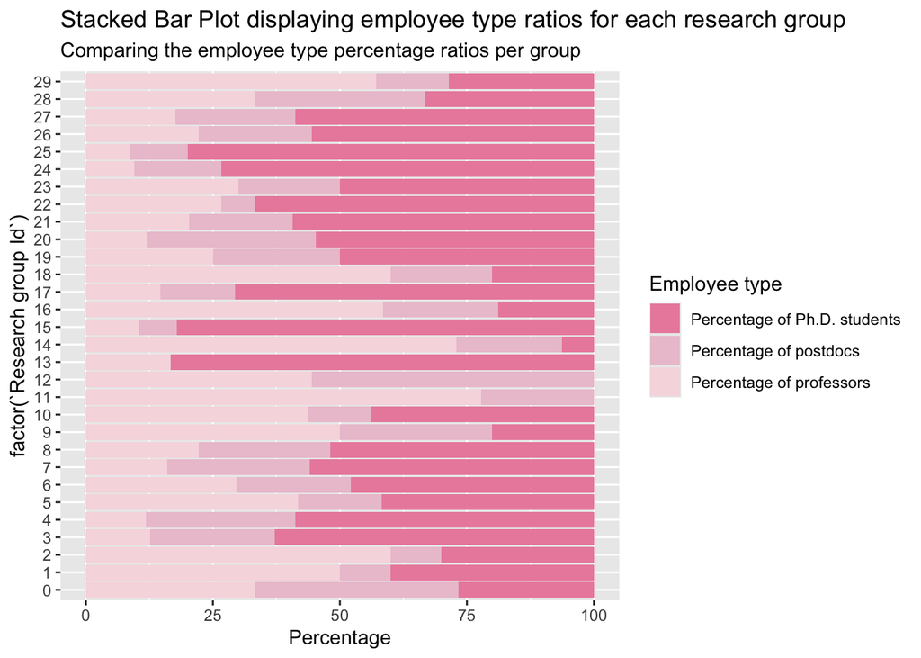

```r
ggplot(data = reShapeFinalColumns,
       mapping = aes(x = factor (`Research group Id`),
                     #factor to display all y-values: id values
                     y =  `Percentage`,
                     fill  = `Employee type`

 )) +

  scale_fill_manual(values = c("#EB8DAB",
                             "#ECC4D3",
                             "#F6DBE1")) +

  geom_col() +
  coord_flip()  +

  labs(title = "Stacked Bar Plot displaying employee type ratios for each research group",
       subtitle = "Comparing the employee type percentage ratios per group")
```

**Credits:**  
Cover page image: [21 Things You Should Know Before Moving to the Netherlands](https://www.movehub.com/uk/moving-abroad/netherlands/things-to-know/)

End of Project 1